```python
import tensorflow as tf
from tensorflow.keras import datasets, layers, models
import matplotlib.pyplot as plt
import tensorflow.keras.datasets.cifar10
from tensorflow.keras.utils import to_categorical
import tensorflow.keras.utils
```

# Convolutioneel neuraal netwerk

in dit opdracht is het bedoelt dat we met de CIFAR-10 dataset een Convolutioneel neuraal netwerk bouwen die dus aan de hand van plaatjes de pixels een predictie kan maken wat voor plaatje het is.

# Creeren van een train en test data set

```python
(train_images, train_labels), (test_images, test_labels) = datasets.cifar10.load_data()
train_images, test_images = train_images / 255.0, test_images / 255.0 # normaliseren van de input data.
```

we creeren de test en train data zodat we later de getrainde model op de test data kunnen uitproberen.

# Valideren van classificaties binnen de train dataset

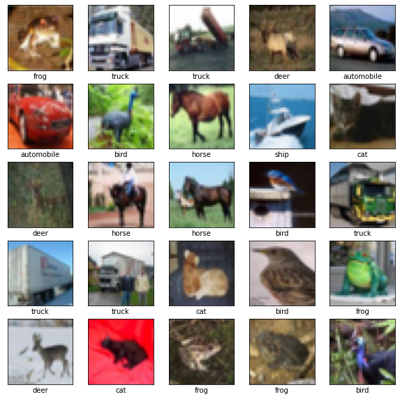

```python
class_names = ['airplane', 'automobile', 'bird', 'cat', 'deer',
               'dog', 'frog', 'horse', 'ship', 'truck']

plt.figure(figsize=(10,10))
for i in range(25):
    plt.subplot(5,5,i+1)
    plt.xticks([])
    plt.yticks([])
    plt.grid(False)
    plt.imshow(train_images[i])
    # The CIFAR labels happen to be arrays,
    # which is why you need the extra index
    plt.xlabel(class_names[train_labels[i][0]])
plt.show()
```

Wanneer we de train data plotten kunnen we zien dat het goed geclassificeerd is.

# kwalitatief modellen

## data preparation

```python
train_labels = tf.keras.utils.to_categorical(train_labels)
test_labels = tf.keras.utils.to_categorical(test_labels)
```

zoals in de opdracht is beschreven moesten we kwalitatief en kwantitatief model maken. hier maken we eerst een kwalitatief. dit kunnen we realiseren door de train labels en test labels om te zetten naar categoricale waardes.

## Baseline model

```python
model = models.Sequential()
# layer 1
model.add(layers.Conv2D(32, (3, 3), activation='relu', input_shape=(32, 32, 3)))

# layer 2
model.add(layers.Conv2D(32, (3, 3), activation='relu'))
model.add(layers.MaxPooling2D((2, 2)))
```

Hier creeren we een base model met 2 layers waar (32, 32) neuronen in zitten. ook gebruiken we de activatie functie van Relu. ook specificeren we dat de model een input shape heeft van 32 pixels bij 32 pixel bij 3.

```python
model.add(layers.Flatten())
```

```python
# layer 3
model.add(layers.Dense(32, activation='relu'))
# layer 4 (output layer)
model.add(layers.Dense(10, activation='softmax'))
```

we voegen ook een dense layer zodat er classificatie kan komen. hoe dit werkt is dat de laatse tensor output door de dense layer komt waarbij we dus een classificatie output kunnen krijgen. aangezien de CIFAR dataset een output classe heeft van 10. maken we dus een dense layer met 10 outputs

### Compiling en training van de baseline model

```python
model.compile(optimizer='adam', loss='categorical_crossentropy', metrics=['accuracy'])

base_line_history = model.fit(train_images, train_labels, epochs=20, validation_split = 0.2, batch_size = 64)
```

we compilen de base model. ook fitten we de model en loopt het op 20 epochs.

```
313/313 - 2s - loss: 1.3666 - accuracy: 0.6401 - 2s/epoch - 5ms/step
```

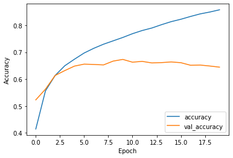

```python
plt.plot(base_line_history.history['accuracy'], label='accuracy')
plt.plot(base_line_history.history['val_accuracy'], label = 'val_accuracy')
plt.xlabel('Epoch')
plt.ylabel('Accuracy')
plt.legend(loc='lower right')

test_loss_baseline, test_acc_baseline = model.evaluate(test_images,  test_labels, verbose=2)
```

gezien de grafiek kunnen we concluderen dat er sprake is van overfitting. dit kunnen we zien doordat de training accuracy stijgt terwijl de validatie accuracy gestabiliseerd rond 4 epochs.

### evalueren

```python
model.summary()
```

```
Model: "sequential_21"
_________________________________________________________________
 Layer (type)                Output Shape              Param #
=================================================================
 conv2d_56 (Conv2D)          (None, 30, 30, 32)        896

 conv2d_57 (Conv2D)          (None, 28, 28, 32)        9248

 max_pooling2d_36 (MaxPoolin  (None, 14, 14, 32)       0
 g2D)

 flatten_21 (Flatten)        (None, 6272)              0

 dense_52 (Dense)            (None, 32)                200736

 dense_53 (Dense)            (None, 10)                330

=================================================================
Total params: 211,210
Trainable params: 211,210
Non-trainable params: 0
_________________________________________________________________
```

### score

```python
print("baseline model accuracy", test_acc_baseline)
print("baseline model loss", test_loss_baseline)
```

```
baseline model accuracy 0.6401000022888184
baseline model loss 1.3665772676467896
```

Op het moment krijgen we een test accuracy van 64 %. dit kan uiteraard veel beter en daarom bouwen we een beter model met meer layers en meer neuronen bovenop. eventueel kunnen we gebruik maken van learning scheduler.

## model (3 layers)

```python
model = models.Sequential()
# layer 1
model.add(layers.Conv2D(32, (3, 3), activation='relu', input_shape=(32, 32, 3)))

# layer 2
model.add(layers.Conv2D(64, (3, 3), activation='relu'))
model.add(layers.MaxPooling2D((2, 2)))

# layer 3
model.add(layers.Conv2D(64, (3, 3), activation='relu'))
```

```python
model.add(layers.Flatten())
```

```python
# layer 4
model.add(layers.Dense(64, activation='relu'))
# layer 5 (output layer)
model.add(layers.Dense(10, activation='softmax'))
```

### Compiling en training van de verbeterd model (3 layers)

```python
model.compile(optimizer='adam', loss='categorical_crossentropy', metrics=['accuracy'])

model_01 = model.fit(train_images, train_labels, epochs=20, validation_split = 0.2, batch_size = 64)
```

```
313/313 - 2s - loss: 2.2496 - accuracy: 0.6726 - 2s/epoch - 7ms/step
```

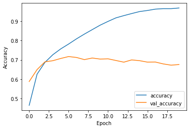

```python
plt.plot(model_01.history['accuracy'], label='accuracy')
plt.plot(model_01.history['val_accuracy'], label = 'val_accuracy')
plt.xlabel('Epoch')
plt.ylabel('Accuracy')
plt.legend(loc='lower right')

test_loss_verbeterd_model, test_acc_verbeterd_model = model.evaluate(test_images,  test_labels, verbose=2)
```

We zien dat de model nogsteeds overfit is. dit gaan we met verbeterde modellen oplossen door de modellen meer complexer te maken.

```
313/313 - 2s - loss: 2.2496 - accuracy: 0.6726 - 2s/epoch - 7ms/step
```

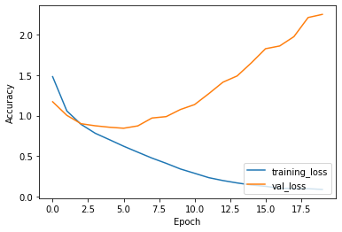

```python
plt.plot(model_01.history['loss'], label='training_loss')
plt.plot(model_01.history['val_loss'], label = 'val_loss')
plt.xlabel('Epoch')
plt.ylabel('Accuracy')
plt.legend(loc='lower right')

test_loss, test_acc = model.evaluate(test_images,  test_labels, verbose=2)
```

Ook wanneer we de training loss plotten kunnen we duidelijk zien dat er overfitting. dit gebeurd zoals we zien rond 5 epochs.

### evaluatie

```python
model.summary()
```

```
Model: "sequential_22"
_________________________________________________________________
 Layer (type)                Output Shape              Param #
=================================================================
 conv2d_58 (Conv2D)          (None, 30, 30, 32)        896

 conv2d_59 (Conv2D)          (None, 28, 28, 64)        18496

 max_pooling2d_37 (MaxPoolin  (None, 14, 14, 64)       0
 g2D)

 conv2d_60 (Conv2D)          (None, 12, 12, 64)        36928

 flatten_22 (Flatten)        (None, 9216)              0

 dense_54 (Dense)            (None, 64)                589888

 dense_55 (Dense)            (None, 10)                650

=================================================================
Total params: 646,858
Trainable params: 646,858
Non-trainable params: 0
_________________________________________________________________
```

### score

```python
print("verbeterd model accuracy", test_acc_verbeterd_model)
print("verbeterd model loss", test_loss_verbeterd_model)
```

```
verbeterd model accuracy 0.6725999712944031
verbeterd model loss 2.2496390342712402
```

## model (4 layers) (3 dense layers) (learning rate scheduler)

```python
model = models.Sequential()

# layer 1
model.add(layers.Conv2D(32, (3, 3), activation='relu', input_shape=(32, 32, 3)))

# layer 2
model.add(layers.Conv2D(64, (3, 3), activation='relu'))
model.add(layers.MaxPooling2D((2, 2)))

# layer 3
model.add(layers.Conv2D(64, (3, 3), activation='relu'))

# layer 4
model.add(layers.Conv2D(128, (3, 3), activation='relu'))
model.add(layers.MaxPooling2D((2, 2)))
```

```python
model.add(layers.Flatten())
```

```python
# layer 5
model.add(layers.Dense(64, activation='relu'))
# layer 6
model.add(layers.Dense(64, activation='relu'))
# layer 7
model.add(layers.Dense(64, activation='relu'))
# layer 8 (output layer)
model.add(layers.Dense(10, activation='softmax'))
```

### learning rate scheduler

```python
def scheduler(epoch, lr):
    if epoch < 10:
        return lr
    else:
        return lr * tf.math.exp(-0.1)
```

```python
callback = tf.keras.callbacks.LearningRateScheduler(scheduler)
```

```python
model.compile(optimizer='adam', loss='categorical_crossentropy', metrics=['accuracy'])
model_02 = model.fit(train_images, train_labels, epochs=20, validation_split = 0.2, batch_size = 64, callbacks=[callback])
```

```
313/313 - 2s - loss: 1.8537 - accuracy: 0.7204 - 2s/epoch - 7ms/step
```

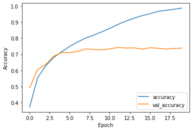

```python
plt.plot(model_02.history['accuracy'], label='accuracy')
plt.plot(model_02.history['val_accuracy'], label = 'val_accuracy')
plt.xlabel('Epoch')
plt.ylabel('Accuracy')
plt.legend(loc='lower right')

test_loss_verbeterd_model_2, test_acc_verbeterd_model_2 = model.evaluate(test_images,  test_labels, verbose=2)
```

We zien dat bij dit model nogsteeds sprake van overfitting is. bij de volgende model gaan we dit proberen te voorkomen door layer regulizars te gebruiken en andere optimization technieken.

### evaluatie

```python
model.summary()
```

[output not shown]

### score

```python
print("verbeterd model accuracy", test_acc_verbeterd_model_2)
print("verbeterd model loss", test_loss_verbeterd_model_2)
```

```
verbeterd model accuracy 0.7203999757766724
verbeterd model loss 1.8537392616271973
```

We kwamen uiteindelijk op een model accuracy van 72 %. dit is uiteraard wat beter dan de voorgaande modellen maar toch niet helemaal wat we willen.we kunnen dit model veel beter maken door meerdere optimization technieken te gebruiken.

## model (6 layers) (4 dense layers) learning scheduler, BatchNormalization, layer weight regularisation

### data augmentation

```python
datagenerate = tf.keras.preprocessing.image.ImageDataGenerator(rotation_range=15, width_shift_range=0.1,height_shift_range=0.1,horizontal_flip=True, validation_split=0.2)
datagenerate.fit(train_images)
```

```python
def scheduler(epoch, lr):
    if epoch < 10:
        return lr
    else:
        return lr * tf.math.exp(-0.1)
```

```python
callback = tf.keras.callbacks.LearningRateScheduler(scheduler)
```

We maken een learning rate scheduler aan om na de 10 epochs de learning rate exponentieel te verlagen met 0.1

```python
model = models.Sequential()

# layer 1
model.add(layers.Conv2D(32, (3, 3), activation='relu', input_shape=(32, 32, 3), kernel_regularizer=tf.keras.regularizers.l2(0.0001)))
model.add(layers.BatchNormalization())


# layer 2
model.add(layers.Conv2D(64, (3, 3), activation='relu', kernel_regularizer=tf.keras.regularizers.l2(0.0001)))
model.add(layers.MaxPooling2D((2, 2)))
model.add(layers.BatchNormalization())
# layer 3
model.add(layers.Conv2D(64, (3, 3), activation='relu', kernel_regularizer=tf.keras.regularizers.l2(0.0001)))
model.add(layers.BatchNormalization())

# layer 4
model.add(layers.Conv2D(128, (3, 3), activation='relu', kernel_regularizer=tf.keras.regularizers.l2(0.0001)))
model.add(layers.MaxPooling2D((2, 2)))
model.add(layers.BatchNormalization())
# layer 5
model.add(layers.Conv2D(128, (3, 3), activation='relu', kernel_regularizer=tf.keras.regularizers.l2(0.0001)))
model.add(layers.BatchNormalization())

# layer 6
model.add(layers.Conv2D(128, (3, 3), activation='relu', kernel_regularizer=tf.keras.regularizers.l2(0.0001)))
model.add(layers.BatchNormalization())
```

```python
model.add(layers.Flatten())
```

```python
# layer 7
model.add(layers.Dense(128, activation='relu', kernel_regularizer=tf.keras.regularizers.l2(0.0001)))
model.add(layers.BatchNormalization())
# layer 8
model.add(layers.Dense(64, activation='relu', kernel_regularizer=tf.keras.regularizers.l2(0.0001)))
model.add(layers.BatchNormalization())
# layer 9
model.add(layers.Dense(32, activation='relu', kernel_regularizer=tf.keras.regularizers.l2(0.0001)))
model.add(layers.BatchNormalization())
# layer 10 (output layer)
model.add(layers.Dense(10, activation='softmax', kernel_regularizer=tf.keras.regularizers.l2(0.0001)))
```

## compiling & training

```python
model.compile(optimizer='adam', loss='categorical_crossentropy', metrics=['accuracy'])
model_03 = model.fit(datagenerate.flow(train_images, train_labels, batch_size = 64), epochs=38, validation_data=datagenerate.flow(train_images, train_labels, batch_size=16, subset='validation'), callbacks=[callback])
```

```
313/313 - 4s - loss: 0.4996 - accuracy: 0.8826 - 4s/epoch - 13ms/step
```

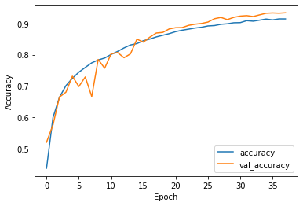

```python
plt.plot(model_03.history['accuracy'], label='accuracy')
plt.plot(model_03.history['val_accuracy'], label = 'val_accuracy')
plt.xlabel('Epoch')
plt.ylabel('Accuracy')
plt.legend(loc='lower right')

test_loss_verbeterd_model_3, test_acc_verbeterd_model_3 = model.evaluate(test_images,  test_labels, verbose=2)
```

Zo als we bij de plot kunnen zien is er geen sprake meer van overfitting. ook zien we dat het na 35 epochs veel stabieler word waardoor we kunnen concluderen dat de max epochs voor dit model rond de 35 zit.

```python
print("verbeterd model accuracy", test_acc_verbeterd_model_3)
print("verbeterd model loss", test_loss_verbeterd_model_3)
```

```
verbeterd model accuracy 0.8826000094413757
verbeterd model loss 0.4995979368686676
```

we krijgen nu een veel beter resultaat. een test accuracy van 88 procent. dit is natuurlijk een veel beter accuracy dan de voorgaande modellen.

## evaluatie

```python
model.summary()
```

```
Model: "sequential_6"
_________________________________________________________________
 Layer (type)                Output Shape              Param #
=================================================================
 conv2d_36 (Conv2D)          (None, 30, 30, 32)        896

 batch_normalization_54 (Bat  (None, 30, 30, 32)       128
 chNormalization)

 conv2d_37 (Conv2D)          (None, 28, 28, 64)        18496

 max_pooling2d_12 (MaxPoolin  (None, 14, 14, 64)       0
 g2D)

 batch_normalization_55 (Bat  (None, 14, 14, 64)       256
 chNormalization)

 conv2d_38 (Conv2D)          (None, 12, 12, 64)        36928

 batch_normalization_56 (Bat  (None, 12, 12, 64)       256
 chNormalization)

 conv2d_39 (Conv2D)          (None, 10, 10, 128)       73856

 max_pooling2d_13 (MaxPoolin  (None, 5, 5, 128)        0
 g2D)

 batch_normalization_57 (Bat  (None, 5, 5, 128)        512
 chNormalization)

 conv2d_40 (Conv2D)          (None, 3, 3, 128)         147584

 batch_normalization_58 (Bat  (None, 3, 3, 128)        512
 chNormalization)

 conv2d_41 (Conv2D)          (None, 1, 1, 128)         147584

 batch_normalization_59 (Bat  (None, 1, 1, 128)        512
 chNormalization)

```

[output cut: 9 more lines]

```
 batch_normalization_61 (Bat  (None, 64)               256
 chNormalization)

 dense_26 (Dense)            (None, 32)                2080

 batch_normalization_62 (Bat  (None, 32)               128
 chNormalization)

 dense_27 (Dense)            (None, 10)                330

=================================================================
Total params: 455,594
Trainable params: 454,058
Non-trainable params: 1,536
_________________________________________________________________
```

# conclusie